# DataSet Study - Who Suicide 1950-2021

### 4.8 Graphic Analysis - Suicide by Generation

#### Regarding this analysis, I will show the numbers of suicides according to the crossing of ages between generations and using only a sample of countries that appeared every year in this dataset, this way we can show the analysis avoiding prejudice.

#### Graphic Analysis - Suicide Rate between 20 to 39 years old (Generations: Silent Generation, Baby Boomers, Generation X and Millenial) - Countries with data inserted in most years this dataset.

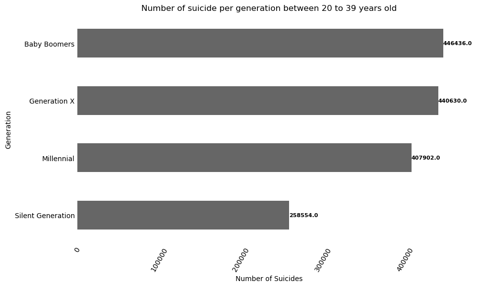

```python
# Side bar chart visualization

plt.figure(figsize=(10,6))

# Grouping data by analyzing only generations Silent Generation, Baby Boomers, Generation X e Millenial between 20 to 34 years old.
df_filter_age  = df_suicide_1950_2021_New['Age Group'].isin(['[20-24]','[25-29]','[30-34]','[35-39]'])
df_filter_gen  = df_suicide_1950_2021_New['Generation'].isin(['Silent Generation', 'Baby Boomers', 'Generation X', 'Millennial'])
df_filter_country = df_suicide_1950_2021_New['Country Name'].isin(['Iceland',
                                                                   'United Kingdom',
                                                                   'Australia',
                                                                   'United States',
                                                                   'Netherlands',
                                                                   'Spain',
                                                                   'Japan',
                                                                   'Denmark',
                                                                   'Canada',
                                                                   'Switzerland'])
# Applyng filters
df_suicide_filter_20_34 = df_suicide_1950_2021_New.loc[df_filter_age  & df_filter_gen & df_filter_country]

# Grouping of data by sex and calcule sum of suicides in each group
suicides_by_generation = df_suicide_filter_20_34.groupby('Generation')['Number'].sum()

suicides_by_generation = suicides_by_generation.sort_values()


# Plot side bar graphic
barras = suicides_by_generation .plot(kind='barh')

for i, v in enumerate(suicides_by_generation ):
    plt.text(v, i, str(v), ha='left', va='center', fontsize=8, fontweight='bold')



# Add the axes and title
plt.xlabel('Number of Suicides')
plt.ylabel('Generation')
plt.title('Number of suicide per generation between 20 to 39 years old')

plt.xticks(rotation=60)
plt.box(False)
plt.tick_params(axis='x',length=0)
plt.tick_params(axis='y',length=0)

# Show Graphic
plt.show()
```

#### Graphic Analysis - Suicide Rate between 05 to 14 years old (Generations: Millenial, Generation Z and Generation Alpha) - Countries with data inserted in most years this dataset.

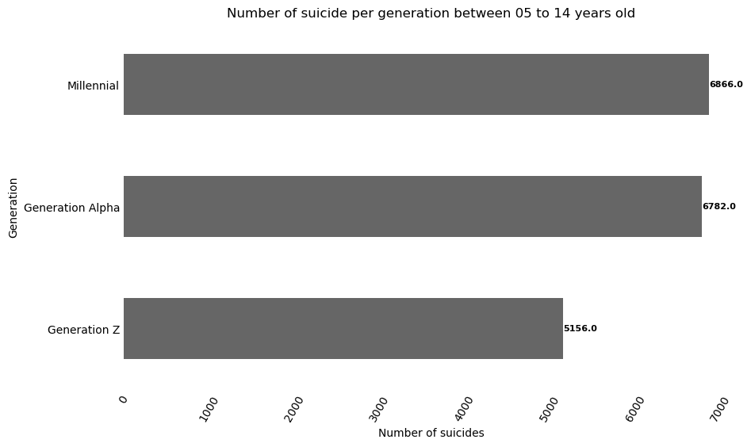

```python
# Side Bar chart visualization

plt.figure(figsize=(10,6))

# Agrupar dados analisando apenas as gerações Silent Generation, Baby Boomers, Generation X e Millenial entre 20 a 34 anos.
df_filter_age  = df_suicide_1950_2021_New['Age Group'].isin(['[05-09]','[10-14]'])
df_filter_gen  = df_suicide_1950_2021_New['Generation'].isin(['Millennial','Generation Z','Generation Alpha'])
df_filter_country = df_suicide_1950_2021_New['Country Name'].isin(['Iceland',
                                                                   'United Kingdom',
                                                                   'Australia',
                                                                   'United States',
                                                                   'Netherlands',
                                                                   'Spain',
                                                                   'Japan',
                                                                   'Denmark',
                                                                   'Canada',
                                                                   'Switzerland'])
# Appçy filters
df_suicide_filter_20_34 = df_suicide_1950_2021_New.loc[df_filter_age  & df_filter_gen & df_filter_country]

# Grouping the data by sex and calcule numbers sum of suicides in each groups.
suicides_by_generation = df_suicide_filter_20_34.groupby('Generation')['Number'].sum()

suicides_by_generation = suicides_by_generation.sort_values()


# Plot Side bar graphic
barras = suicides_by_generation .plot(kind='barh')

for i, v in enumerate(suicides_by_generation ):
    plt.text(v, i, str(v), ha='left', va='center', fontsize=8, fontweight='bold')

# Add labels to the axes and title.
plt.xlabel('Number of suicides')
plt.ylabel('Generation')
plt.title('Number of suicide per generation between 05 to 14 years old')

plt.xticks(rotation=60)
plt.box(False)
plt.tick_params(axis='x',length=0)
plt.tick_params(axis='y',length=0)

# Show plot
plt.show()
```